# lab6_answers

sbsambado

2/4/2021

# Answers for Lab 6

*Notes*

ALL HOMEWORK SHOULD BE SUBMITTED AS A KNITTED HOMEWORK FILE (.PDF or .HTML)

- -2.0 points if HW not in right format
- -.25 point if code is not annotated
- -.25 point if answers are not in complete sentences
- -.25 point if code does not seem adequate to answer question

## **Question 1**

4 points:

- 1 correct hypotheses
- 0.5 boxplot
- 1 checking assumptions
- 0.5 transformation
- 1 correct interpretation of ANOVA

## **Question 2**

4 points:

- 1 correct hypotheses
- 0.5 boxplot
- 0.5 checking assumptions
- 1 correct interpretation of ANOVA
- 1 correct interpretation of Tukey-Kramer

## **Question 3**

2 points:

- 0.25 part A
- 0.25 part B
- 0.25 part C
- 0.25 part D
- 1 point for part E

**Question 1**

A. Clearly state your **null and alternative hypotheses**

```r
# null: the mean malaria incidence doe not differ between the three levels of cultivation
# alternative: Then mean malaria incidence differs for at least one level of cultivation
```

B. Show me a **box plot** (or a means plot) of the data. How many levels are we testing?

```r
malaria <- read_csv("malaria_vs_maize.csv")
```

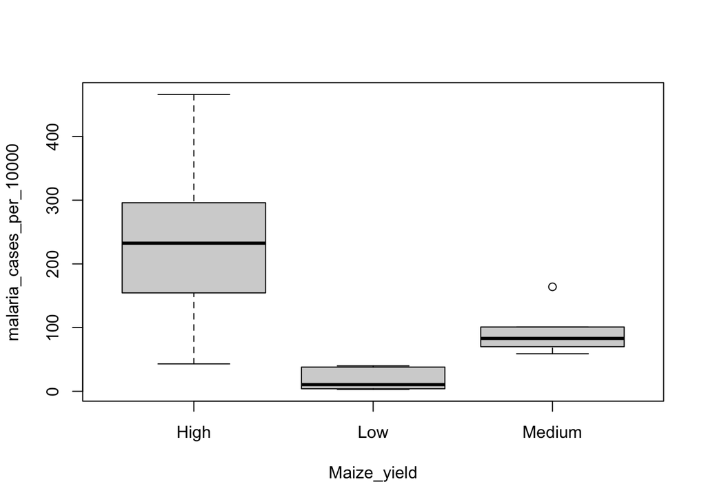

```r
boxplot(malaria_cases_per_10000 ~ Maize_yield, data = malaria)
```

```r
# We are testing 3 levels
```

C. Test the assumptions of normality and homogeneity of variance using the diagnostic plots (i.e. the **residual plot and the qqPlot**) and the **Shapiro-Wilk test and the Levene’s Test**. Based on these tests, what do you conclude about your normality and homogeneity of variance assumptions?

```r
corn1 <- aov(malaria_cases_per_10000 ~ Maize_yield, data=malaria)
summary(corn1)
```

```
##             Df Sum Sq Mean Sq F value   Pr(>F)
## Maize_yield  2 168844   84422   11.23 0.000898 ***
## Residuals   16 120294    7518
## ---
## Signif. codes:  0 '***' 0.001 '**' 0.01 '*' 0.05 '.' 0.1 ' ' 1
```

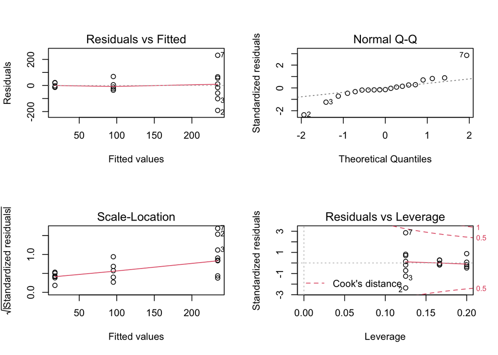

```r
par(mfrow = c(2,2))
plot(corn1)
```

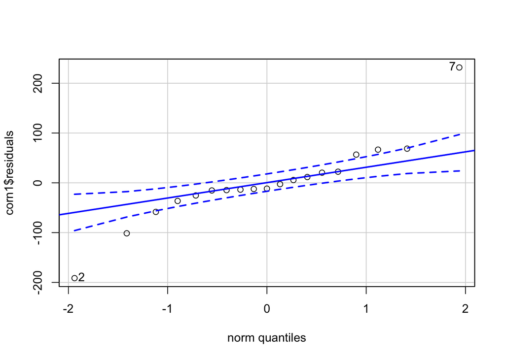

```
## [1] 7 2
```

```r
par(mfrow = c(1,1))

qqPlot(corn1$residuals)
```

```r
leveneTest(malaria_cases_per_10000 ~ Maize_yield, data=malaria)
```

```
## Levene's Test for Homogeneity of Variance (center = median)
##       Df F value  Pr(>F)
## group  2  3.9662 0.03991 *
##       16
## ---
## Signif. codes:  0 '***' 0.001 '**' 0.01 '*' 0.05 '.' 0.1 ' ' 1
```

```r
shapiro.test(corn1$residuals)
```

```
##
##  Shapiro-Wilk normality test
##
## data:  corn1$residuals
## W = 0.88211, p-value = 0.02337
```

```r
# There are clear violations of normality and homogeniety of variance assumptions
```

D. If your assumptions aren’t met try **transforming malaria_cases_per_1000**. After your transformation, **retest your assumptions using the transformed data** with diagnostic plots (i.e. the residual plot and the qqplot) and the Shapiro-Wilk test and the Levene’s Test. Find a transformation that allows for both assumptions to be met. Just report this transformation.

```r
malaria$log_cases <- log(malaria$malaria_cases_per_10000)

leveneTest(log_cases ~ Maize_yield, data = malaria, center = "median") # p = 0.05604
```

```
## Levene's Test for Homogeneity of Variance (center = "median")
##       Df F value  Pr(>F)
## group  2  3.4689 0.05604 .
##       16
## ---
## Signif. codes:  0 '***' 0.001 '**' 0.01 '*' 0.05 '.' 0.1 ' ' 1
```

```r
corn2 <- aov(log_cases ~ Maize_yield, data=malaria)

shapiro.test(corn2$residuals) # p = 0.8875
```

```
##
##  Shapiro-Wilk normality test
##
## data:  corn2$residuals
## W = 0.97606, p-value = 0.8875
```

```r
# based on the above tests, both the homogeneity of variance and normality assumptions are now met. I used a log transformation
```

E. Run an **ANOVA on your transformed data**. Include the ANOVA table generated in the analysis. Using the ANOVA table, conclude whether the level of cultivation significantly affects the number of malaria cases. You don’t need to do any pairwise comparisons for this exercise.

```r
corn2 <- aov(log_cases ~ Maize_yield, data=malaria)

summary(corn2) # p = 2.41e-05
```

```
##             Df Sum Sq Mean Sq F value   Pr(>F)
## Maize_yield  2  29.49  14.744   22.22 2.41e-05 ***
## Residuals   16  10.62   0.663
## ---
## Signif. codes:  0 '***' 0.001 '**' 0.01 '*' 0.05 '.' 0.1 ' ' 1
```

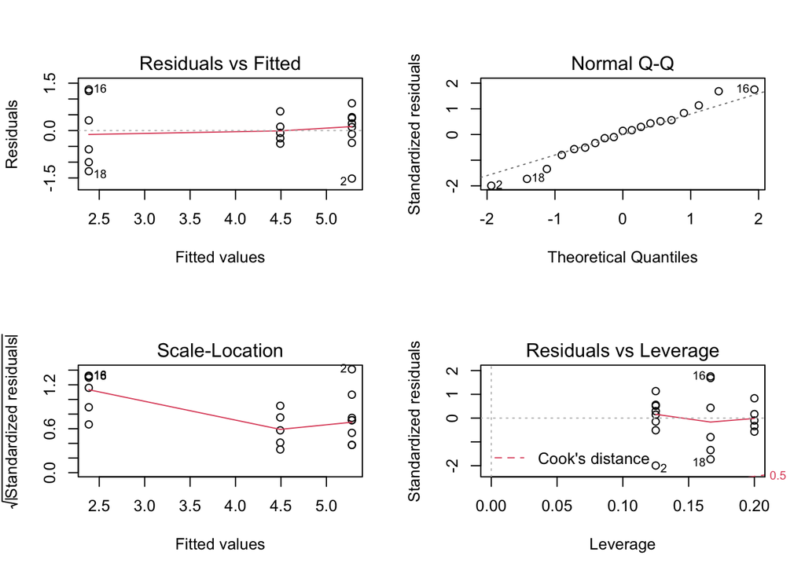

```r
par(mfrow = c(2,2))
plot(corn2)
```

```r
par(mfrow = c(1,1))

# we conclude that cultivation does have a significant effect on the log number of malaria cases
```

**Question 2**

The European cuckoo does not look after its own eggs, but instead lays them in the nests of birds of other species. Cuckoos sometimes have evolved to lay eggs that are colored similarly to the host birds’ eggs. Is the same true of size – do cuckoos lay eggs of different sizes in nests of different hosts? The data file **cuckooeggs.csv** contains data on the lengths of cuckoo eggs laid in a variety of other species’ nests.

Use an ANOVA to test for *a difference in cuckoo egg size for different host species*. Specifically:

A. Clearly state your **null and alternative hypotheses**

```r
# null:The mean size of cuckoo eggs is the same for all host species
# alternative: The mean size of cuckoo eggs is different for at least one host species
```

B. Show me a **box plot** (or a means plot) of the data. How many levels (groups) are we testing?

```r
eggs <- read_csv("cuckooeggs.csv")
```

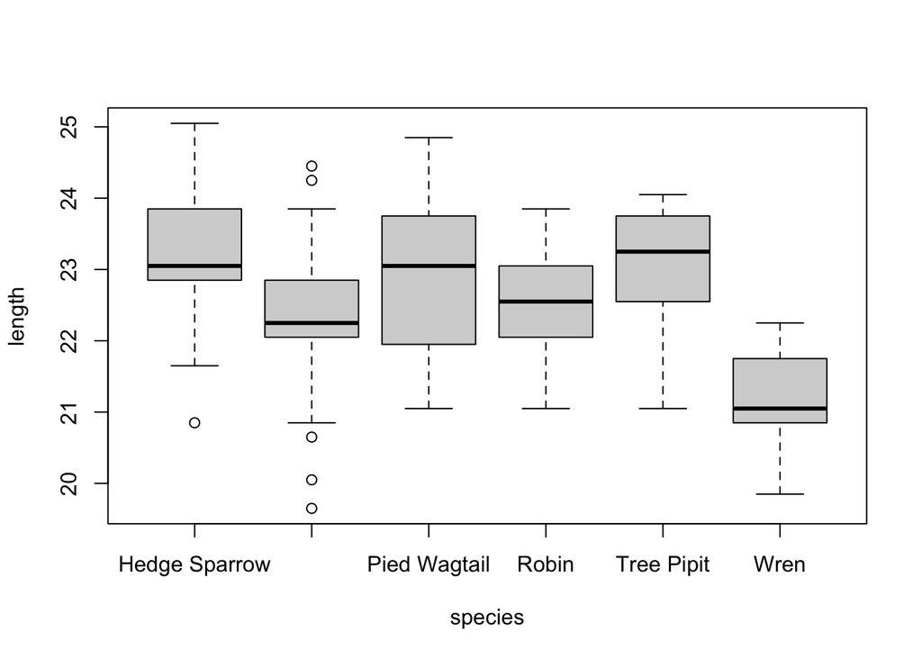

```r
names(eggs) <- c("species", "length")

boxplot(length ~ species, data = eggs)
```

```r
# we are testing 6 levels/groups/species
```

C. Test the **assumptions of normality and homogeneity of variance** using diagnostic plots (i.e. residuals plots and QQplots) and a Shapiro-Wilk test and a Levene’s Test. What do you conclude about your assumptions of normality and homogeneity of variance?

```r
eggs1 <- aov(length ~ species, data = eggs)
summary(eggs1) # p = 3.15e-08
```

```
##              Df Sum Sq Mean Sq F value   Pr(>F)
## species       5  42.94   8.588   10.39 3.15e-08 ***
## Residuals   114  94.25   0.827
## ---
## Signif. codes:  0 '***' 0.001 '**' 0.01 '*' 0.05 '.' 0.1 ' ' 1
```

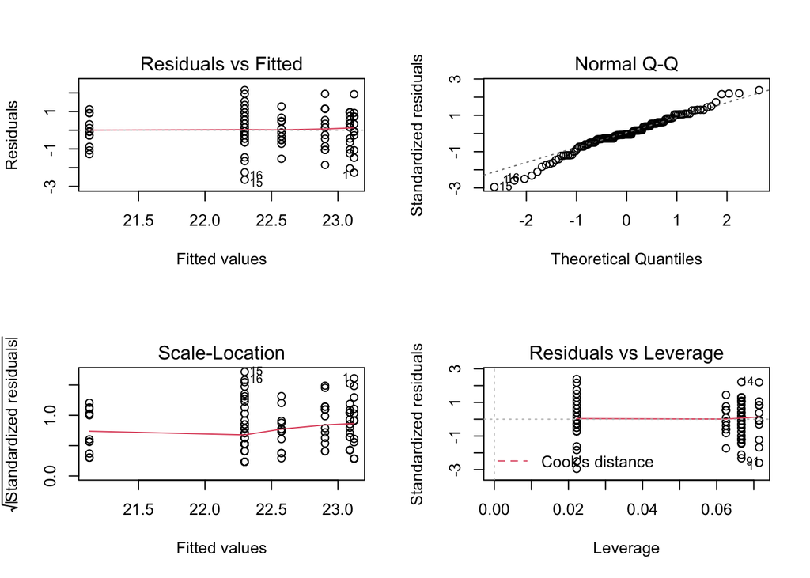

```r
par(mfrow = c(2,2))
plot(eggs1)
```

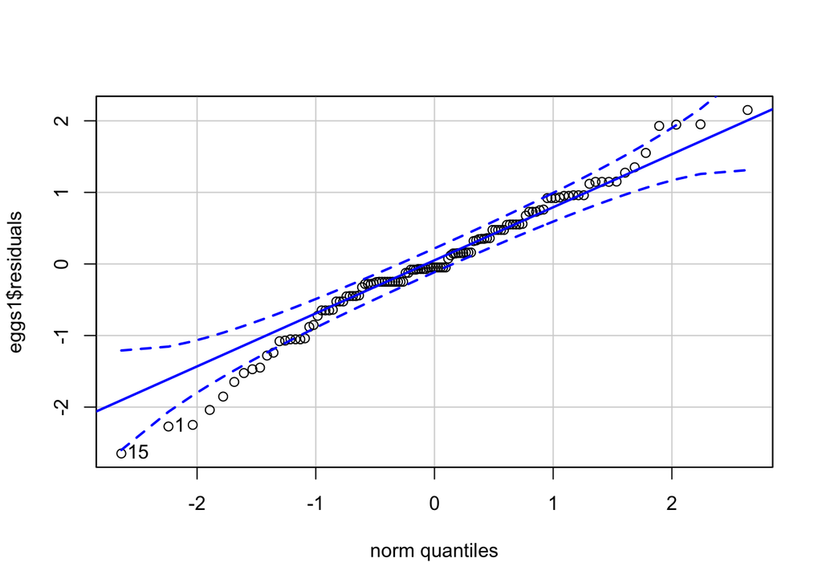

```
## [1] 15  1
```

```r
par(mfrow = c(1,1))


qqPlot(eggs1$residuals)
```

```r
shapiro.test(eggs1$residuals)
```

```
##
##  Shapiro-Wilk normality test
##
## data:  eggs1$residuals
## W = 0.9804, p-value = 0.07761
```

```r
leveneTest(length ~ species, data = eggs, center = "median") # p = 0.6698
```

```
## Levene's Test for Homogeneity of Variance (center = "median")
##        Df F value Pr(>F)
## group   5  0.6397 0.6698
##       114
```

D. If your assumptions aren’t met try a transformation. Otherwise, proceed with your analysis.

```r
# The assumptions of normality and homoegenitiy of variances are met
```

E. Include the **ANOVA table** generated from the analysis. Conclude whether cuckoos lay different size eggs in different bird nests.

```r
eggs1 <- aov(length ~ species, data = eggs)
summary(eggs1) # p = 3.15e-08
```

```
##              Df Sum Sq Mean Sq F value   Pr(>F)
## species       5  42.94   8.588   10.39 3.15e-08 ***
## Residuals   114  94.25   0.827
## ---
## Signif. codes:  0 '***' 0.001 '**' 0.01 '*' 0.05 '.' 0.1 ' ' 1
```

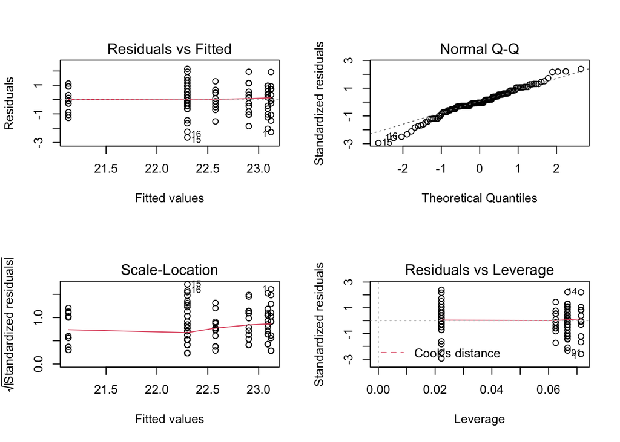

```r
par(mfrow = c(2,2))
plot(eggs1)
```

```r
par(mfrow = c(1,1))

shapiro.test(eggs1$residuals) # p = 0.07761
```

```
##
##  Shapiro-Wilk normality test
##
## data:  eggs1$residuals
## W = 0.9804, p-value = 0.07761
```

```r
leveneTest(length ~ species, data = eggs, center = "median") # p = 0.6698
```

```
## Levene's Test for Homogeneity of Variance (center = "median")
##        Df F value Pr(>F)
## group   5  0.6397 0.6698
##       114
```

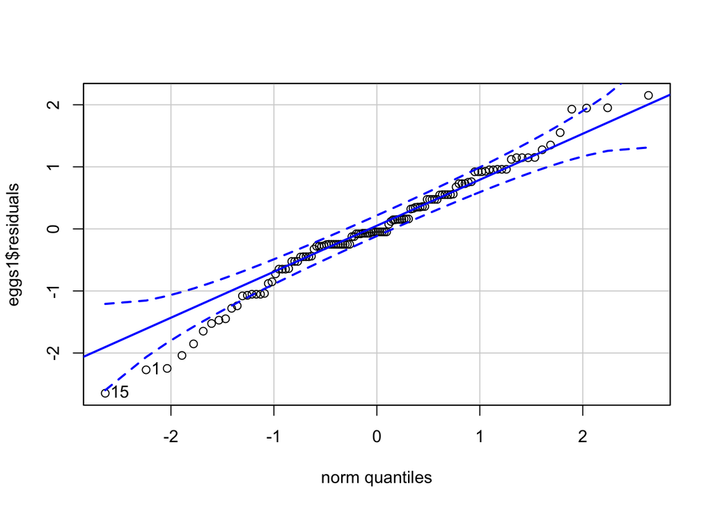

```
## [1] 15  1
```

```r
qqPlot(eggs1$residuals)
```

```r
# Cuckoos lay significantly different sized eggs in different host species's nests
```

F. Perform a **Tukey-Kramer Test** for multiple comparisons. For what bird species does the cuckoo lay the significantly smallest eggs?

```r
eggs$species <- as.factor(eggs$species)
eggs1 <- aov(length ~ species, data = eggs)

TukeyHSD(eggs1)
```

```
##   Tukey multiple comparisons of means
##     95% family-wise confidence level
##
## Fit: aov(formula = length ~ species, data = eggs)
##
## $species
##                                   diff          lwr         upr     p adj
## Meadow Pipit-Hedge Sparrow -0.82253968 -1.629133605 -0.01594576 0.0428621
## Pied Wagtail-Hedge Sparrow -0.21809524 -1.197559436  0.76136896 0.9872190
## Robin-Hedge Sparrow        -0.54642857 -1.511003196  0.41814605 0.5726153
## Tree Pipit-Hedge Sparrow   -0.03142857 -1.010892769  0.94803563 0.9999990
## Wren-Hedge Sparrow         -1.99142857 -2.970892769 -1.01196437 0.0000006
## Pied Wagtail-Meadow Pipit   0.60444444 -0.181375330  1.39026422 0.2324603
## Robin-Meadow Pipit          0.27611111 -0.491069969  1.04329219 0.9021876
## Tree Pipit-Meadow Pipit     0.79111111  0.005291337  1.57693089 0.0474619
## Wren-Meadow Pipit          -1.16888889 -1.954708663 -0.38306911 0.0004861
## Robin-Pied Wagtail         -0.32833333 -1.275604766  0.61893810 0.9155004
## Tree Pipit-Pied Wagtail     0.18666667 -0.775762072  1.14909541 0.9932186
## Wren-Pied Wagtail          -1.77333333 -2.735762072 -0.81090459 0.0000070
## Tree Pipit-Robin            0.51500000 -0.432271433  1.46227143 0.6159630
## Wren-Robin                 -1.44500000 -2.392271433 -0.49772857 0.0003183
## Wren-Tree Pipit            -1.96000000 -2.922428738 -0.99757126 0.0000006
```

```r
Post_hoc <- glht(eggs1, linfct = mcp(species = "Tukey")) # if washing_method is not a factor when you ran the wash1 anova, the glht() will not work

summary(Post_hoc)
```

```
##
##   Simultaneous Tests for General Linear Hypotheses
##
## Multiple Comparisons of Means: Tukey Contrasts
##
##
## Fit: aov(formula = length ~ species, data = eggs)
##
## Linear Hypotheses:
##                                   Estimate Std. Error t value Pr(>|t|)
## Meadow Pipit - Hedge Sparrow == 0 -0.82254    0.27825  -2.956   0.0418 *
## Pied Wagtail - Hedge Sparrow == 0 -0.21810    0.33789  -0.645   0.9868
## Robin - Hedge Sparrow == 0        -0.54643    0.33275  -1.642   0.5657
## Tree Pipit - Hedge Sparrow == 0   -0.03143    0.33789  -0.093   1.0000
## Wren - Hedge Sparrow == 0         -1.99143    0.33789  -5.894   <0.001 ***
## Pied Wagtail - Meadow Pipit == 0   0.60444    0.27109   2.230   0.2274
## Robin - Meadow Pipit == 0          0.27611    0.26466   1.043   0.8994
## Tree Pipit - Meadow Pipit == 0     0.79111    0.27109   2.918   0.0461 *
## Wren - Meadow Pipit == 0          -1.16889    0.27109  -4.312   <0.001 ***
## Robin - Pied Wagtail == 0         -0.32833    0.32678  -1.005   0.9130
## Tree Pipit - Pied Wagtail == 0     0.18667    0.33201   0.562   0.9930
## Wren - Pied Wagtail == 0          -1.77333    0.33201  -5.341   <0.001 ***
## Tree Pipit - Robin == 0            0.51500    0.32678   1.576   0.6094
## Wren - Robin == 0                 -1.44500    0.32678  -4.422   <0.001 ***
## Wren - Tree Pipit == 0            -1.96000    0.33201  -5.903   <0.001 ***
## ---
## Signif. codes:  0 '***' 0.001 '**' 0.01 '*' 0.05 '.' 0.1 ' ' 1
## (Adjusted p values reported -- single-step method)
```

```r
confint(Post_hoc) # shows your lower and upper CI bounds
```

```
##
##   Simultaneous Confidence Intervals
##
## Multiple Comparisons of Means: Tukey Contrasts
##
##
## Fit: aov(formula = length ~ species, data = eggs)
##
## Quantile = 2.8893
## 95% family-wise confidence level
##
##
## Linear Hypotheses:
##                                   Estimate  lwr       upr
## Meadow Pipit - Hedge Sparrow == 0 -0.822540 -1.626504 -0.018576
## Pied Wagtail - Hedge Sparrow == 0 -0.218095 -1.194366  0.758175
## Robin - Hedge Sparrow == 0        -0.546429 -1.507858  0.415001
## Tree Pipit - Hedge Sparrow == 0   -0.031429 -1.007699  0.944842
## Wren - Hedge Sparrow == 0         -1.991429 -2.967699 -1.015158
## Pied Wagtail - Meadow Pipit == 0   0.604444 -0.178813  1.387702
## Robin - Meadow Pipit == 0          0.276111 -0.488568  1.040791
## Tree Pipit - Meadow Pipit == 0     0.791111  0.007854  1.574369
## Wren - Meadow Pipit == 0          -1.168889 -1.952146 -0.385631
## Robin - Pied Wagtail == 0         -0.328333 -1.272516  0.615849
## Tree Pipit - Pied Wagtail == 0     0.186667 -0.772624  1.145957
## Wren - Pied Wagtail == 0          -1.773333 -2.732624 -0.814043
## Tree Pipit - Robin == 0            0.515000 -0.429183  1.459183
## Wren - Robin == 0                 -1.445000 -2.389183 -0.500817
## Wren - Tree Pipit == 0            -1.960000 -2.919291 -1.000709
```

```r
cld(Post_hoc) #compact letter display of Tukey groups
```

```
## Hedge Sparrow  Meadow Pipit  Pied Wagtail         Robin    Tree Pipit
##           "c"           "b"          "bc"          "bc"           "c"
##          Wren
##           "a"
```

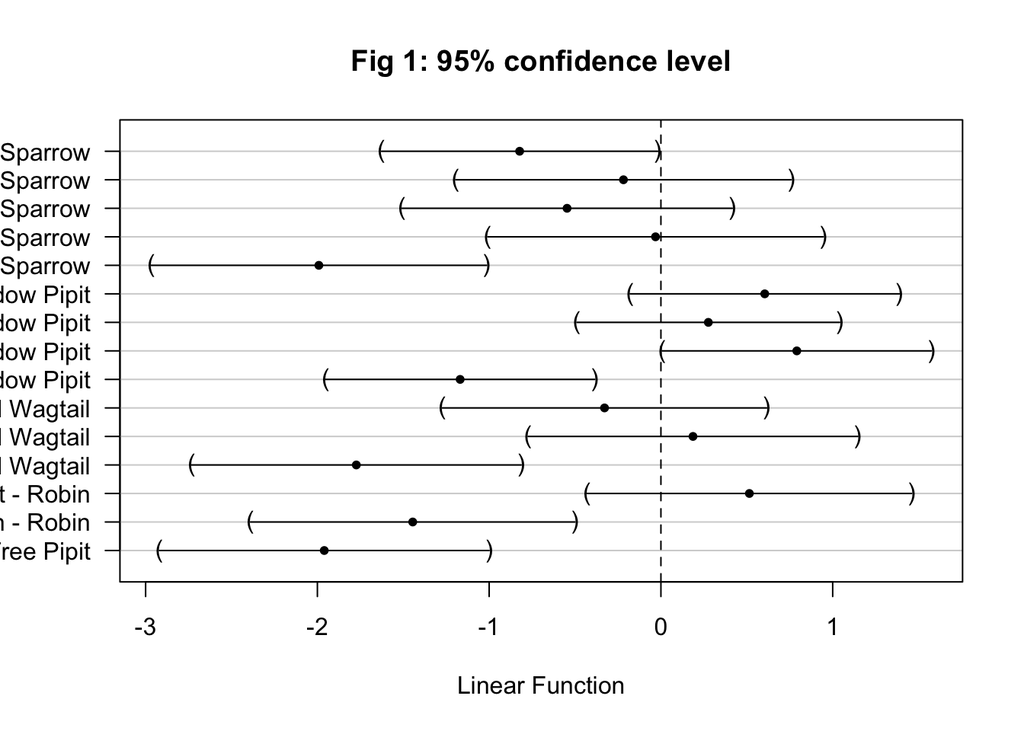

```r
plot(Post_hoc, main = "Fig 1: 95% confidence level") #confidence intervals plotted
```

```r
#
# The cuckoo lays the smallest eggs in the Wren nest
```

**Question 3** A. One factor that could bias the experiment is how much the student drank the night before. Another factor that could bias the experiment is whether or not you blinded the experiment.

B. Approximately 25 students in each group to have a power of 0.8

C. We would now need to sample approximately 38 students in each group to have a power of 0.8

D. Now I would need only about 12 students to have 0.8 power

E. If there is larger variance we will need more samples to have equivalent power. If there is a bigger difference between the treatment and control we will need fewer samples to detect the true difference.